# Reproducible Research

Eslam Ghazal

## Introduction

It is now possible to collect a large amount of data about personal movement using activity monitoring devices

such as a [Fitbit](http://www.fitbit.com/), [Nike Fuelband](http://www.nike.com/us/en_us/c/nikeplus-fuelband), or [Jawbone Up](https://jawbone.com/up). These type of devices are part of the “quantified self” movement

a group of enthusiasts who take measurements about themselves regularly to improve their health, to find patterns

in their behavior, or because they are tech geeks. But these data remain under-utilized both because the raw data

are hard to obtain and there is a lack of statistical methods and software for processing and interpreting the data.

This assignment makes use of data from a personal activity monitoring device. This device collects data

at 5 minute intervals through out the day. The data consists of two months of data from an anonymous

individual collected during the months of October and November, 2012 and include the number of steps

taken in 5 minute intervals each day.

**The data for this assignment can be downloaded from the course web site:**

- **Dataset:** [Activity monitoring data](https://d396qusza40orc.cloudfront.net/repdata%2Fdata%2Factivity.zip) [52k]

**The variables included in this dataset are:**

- **steps**: Number of steps taking in a 5-minute interval (missing values are coded as NA)
- **date**: The date on which the measurement was taken in YYYY-MM-DD format
- **interval**: Identifier for the 5-minute interval in which measurement was taken

## loading required libraries

```r
library(readr)
library(stringr)
library(tidyr)
library(dplyr)
library(purrr)
library(lubridate)
library(ggplot2)
```

## Importing data

```r
activity <- read_csv("activity.csv")
```

## What is mean total number of steps taken per day?

1. Calculate the total number of steps taken per day

```r
activity1 <- activity %>%
    filter(!is.na(steps)) %>%
    group_by(date) %>%
    summarise(steps = sum(steps))
```

2. Make a histogram of the total number of steps taken each day

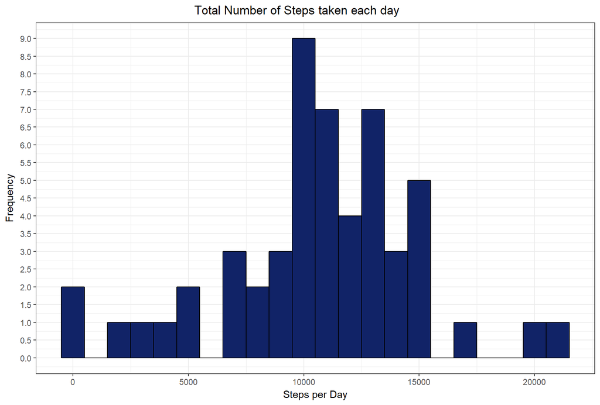

```r
activity1 %>%
ggplot(aes(x = steps))+
    geom_histogram(fill = "#112367", color = "black", binwidth = 1000) +
    labs(title = str_wrap("Total Number of Steps taken each day", indent = 45),
         x = "Steps per Day",
         y = "Frequency")+
    scale_y_continuous(breaks = c(seq(0,10,by = .5)))+
    theme_bw()
```

3. Calculate and report the mean and median of the total number of steps taken per day

```r
steps_mean <- as.integer(round(mean(activity1$steps)))
steps_median <- as.integer(round(median(activity1$steps)))
```

The Mean of the steps equals 10766, while the Median equals 10765

## What is the average daily activity pattern?

1. Transforming data

```r
activity2 <- activity %>%
    filter(!is.na(steps), !is.na(interval)) %>%
    mutate(
        hrs = parse_character(interval %/% 100),
        mins =parse_character(interval %% 100),
        hrs = ifelse(str_length(hrs) == 1, str_c("0", hrs, sep = ""), hrs),
        mins = ifelse(str_length(mins) == 1, str_c("0", mins, sep = ""), mins)) %>%
    unite(time, hrs, mins, sep = ":") %>%
    mutate(
        time = parse_time(time, "%H:%M"))%>%
    group_by(time) %>%
    summarise(steps = mean(steps))
```

2. Plotting

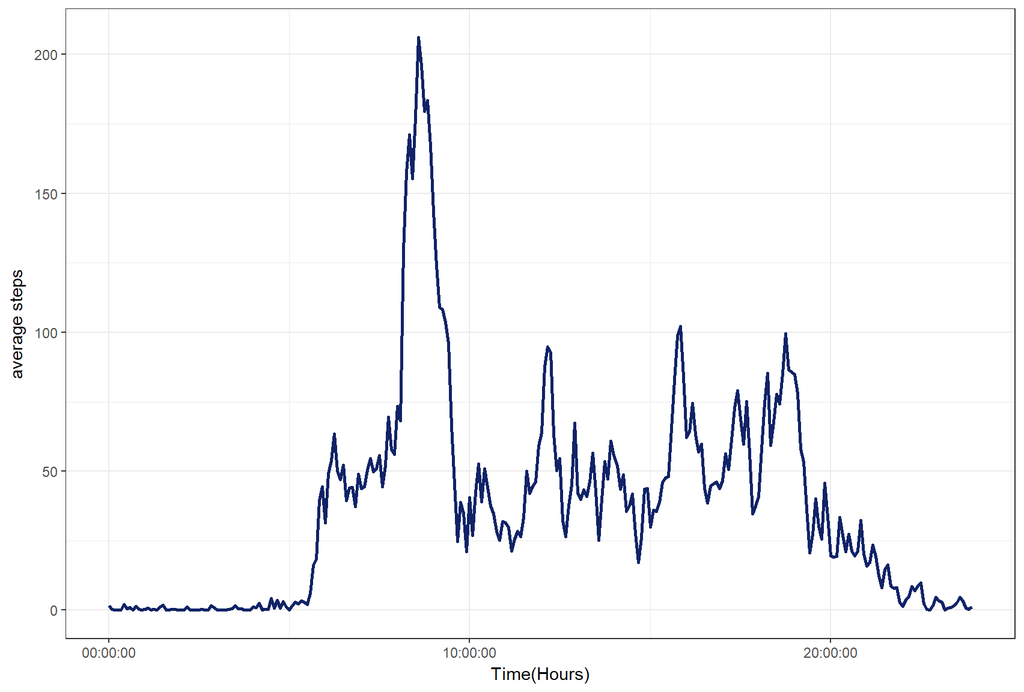

```r
activity2 %>%
    ggplot(aes(time, steps))+
    geom_line(color = "#112367", size = 1)+
    labs(x = "Time(Hours)", y = "average steps")+
    theme_bw()
```

3. Which 5-minute interval, on average across all the days, contains the maximum number of steps?

```r
activity2 <- activity2 %>%
    filter(steps == max(steps))
stringr::str_c("The Maximum Number of Steps equals: ",
               round(activity2$steps),
               " at Time equals: ",
               activity2$time)
```

```
## [1] "The Maximum Number of Steps equals: 206 at Time equals: 08:35:00"
```

## Imputing missing values

*Note that there are a number of days/intervals where there are missing values (coded as NA)*

1. Calculate and report the total number of missing values in the dataset (i.e. the total number of rows with NAs)

```r
steps_missing <- sum(is.na(activity$steps))
```

The Total Number of Missing Values is 2304

2. Devise a strategy for filling in all of the missing values in the dataset.

*I think the best strategy is to replace missing values with the most recent Non-missing value*

```r
steps_non.missing <- activity %>%
    group_by(date) %>%
    filter(!every(steps,is.na)) %>%
    fill(steps)
```

3. Create a new dataset that is equal to the original dataset but with the missing data filled in.

```r
activity3 <- steps_non.missing %>%
    left_join(activity, by = c("date", "interval")) %>%
    select(-steps.y) %>%
    rename(steps = steps.x)
```

4. Make a histogram of the total number of steps taken each day

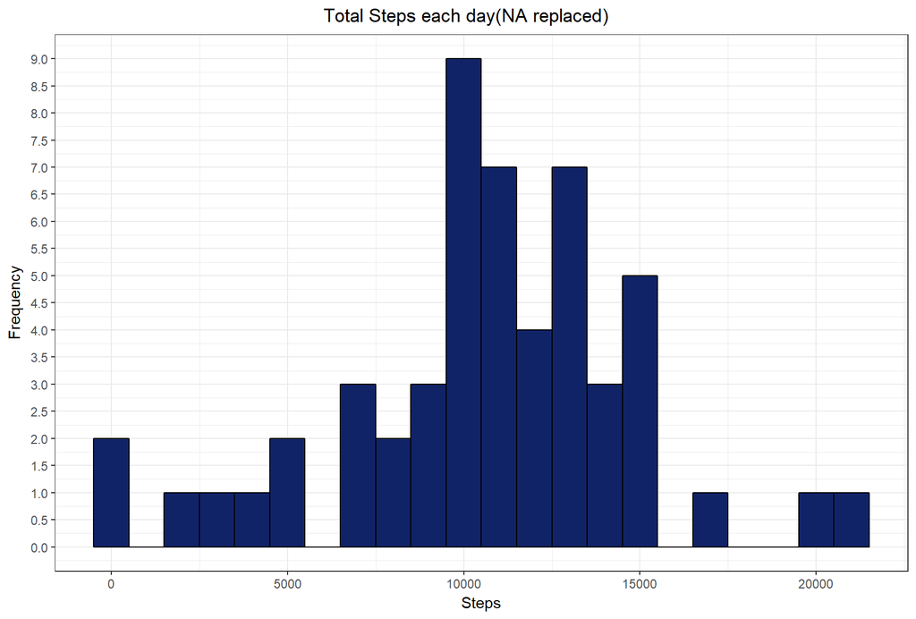

```r
activity3 %>%
    group_by(date) %>%
    summarise(steps = sum(steps))%>%
    ggplot(aes(x = steps))+
    geom_histogram(fill = "#112367", color = "black", binwidth = 1000) +
    scale_y_continuous(breaks = c(seq(0,10,by = .5)))+
    labs(title = str_wrap("Total Steps each day(NA replaced)",indent = 50),
         x = "Steps",
         y = "Frequency")+
    theme_bw()
```

And Calculate and report the mean and median total number of steps taken per day

```r
steps_non.missing <- steps_non.missing %>%
    group_by(date) %>%
    summarise(steps = sum(steps)) %>%
    summarise (mean = as.integer(mean(steps)), median = as.integer(median(steps)))
```

Average Total Number of Steps is 10766, and Median is 10765

## Are there differences in activity patterns between weekdays and weekends?

1. Transforming data

```r
activity4 <- activity %>%
    filter(!is.na(steps), !is.na(interval)) %>%
    mutate(
        hrs = parse_character(interval %/% 100),
        mins =parse_character(interval %% 100),
        hrs = ifelse(str_length(hrs) == 1, str_c("0", hrs, sep = ""), hrs),
        mins = ifelse(str_length(mins) == 1, str_c("0", mins, sep = ""), mins)) %>%
    unite(time, hrs, mins, sep = ":") %>%
    mutate(
        time = parse_time(time, "%H:%M"),
        week_type = ifelse(wday(date, label = TRUE) %in% c("Sun","Sat"), "Weekend", "Weekday")) %>%
    group_by(time, week_type) %>%
    summarise(steps = mean(steps))
```

2. Plotting

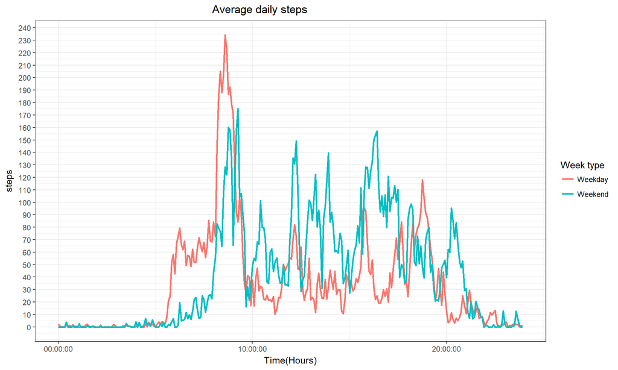

```r
activity4 %>%
    ggplot(aes(x = time, y = steps, color = week_type))+
    geom_line(size = 1)+
    scale_y_continuous(breaks = seq(0, 240, by = 10))+
    theme_bw() +
    labs(color = "Week type", title = str_wrap("Average daily steps", indent = 55), x = "Time(Hours)")
```